# Laboratorio 2.1: Clasificación

Felipe Bravo-Marquez, Hernán Sarmiento, Jocelyn Dunstan, Cinthia Sánchez, Jorge Ortiz, Victor Faraggi, Alison Fernandez Blanco

Abril 2022

# Declaración de compromiso ético

Nosotros: **Sebastián Cobaise y Arturo Lazcano**, declaramos que realizamos de manera grupal los pasos de la presente actividad. También declaramos no incurrir en copia, ni compartir nuestras respuestas con otras personas ni con otros grupos. Por lo que, ratificamos que las respuestas son de nuestra propia confección y reflejan nuestro propio conocimiento.

# Instrucciones

1. Trabajen en equipos de dos personas. Salvo excepciones, no se corregirá entregas con menos de dos integrantes.
2. Modifique este archivo `.ipynb` agregando sus respuestas donde corresponda.
3. El formato de entrega para esta actividad es un archivo **html**. Genere un archivo HTML usando jupyter (ver tutorial 2) y súbalo a U-Cursos. Basta con que **uno de los integrantes haga la entrega**. Si ambos hacen una entrega en U-Cursos, se revisará cualquiera de éstas.

# Estructura del laboratorio

Este laboratorio está conformado por preguntas teóricas de temas vistos en clases y preguntas prácticas (donde se requiere completar código) intercaladas con preguntas de interpretación de resultados y análisis. La parte práctica se divide en:

1. Explorar los datos.
2. Entrenar un clasificador de 3 maneras:
   - Entrenando/Testeando con los mismos datos,
   - Dividiendo el dataset en una parte para entrenar y otra para testear, y
   - Usando cross-validation.

# Teoría

#### 1. Describa los componentes principales de un clasificador.

**Respuesta: Se necesita:**

**-un conjunto de entrenamientos, donde se conoce la clase real de los datos.**

**-El algoritmo de clasificación a utilizar**

**-Un conjunto de validación, donde se sabe la clase real de los datos, pero no se ocupará para entrenar el modelo, sino probarlo**

#### 2. Un consultor en minería de datos tiene la siguiente estrategia al momento de enfrentar un problema de clasificación: probar todos los modelos posibles hasta encontrar uno que tenga cero error de entrenamiento. Comente la estrategia del consultor y proponga una estrategia alternativa para evaluar el desempeño de los modelos.

**Respuesta: La estrategia del consultor no es buena, es extremadamente difícil obtener un error de de cero (sino imposible), por lo que no se espera que un clasificador tenga error cero, sino que sea lo menor posible comparado con otros.**

**Una estrategia alternativa es calcular el error de entrenamiento de cada modelo al hacer cross-validation y elegir aquel que tenga menor error promedio (por ejemplo, el score $F_1$ o ROC AUC)**

#### 3. El mismo consultor siempre usa la misma métrica para evaluar un modelo: accuracy. Comente la estrategia del consultor y proponga una estrategia alternativa. Considere las distintas opciones sobre el balance de los datos.

**Respuesta: El accuracy si nos da información util sobre que tan bueno es un modelo, funciona bien cuando hay una distribución parecida entre las posibles clases (por ejemplo, 50/50 de proporción entre 2 clases "Si" y "No"), así que la estrategia del consultor si puede servir en este caso.**

**Sin embargo, en el caso de que se desee predecir una clase que esté muy poco presente en comparación a otra clase, el Accuracy puede resultar incertero.**

**Por ejemplo si 10% de los datos son del tipo "Con Covid" y 90% "Sin Covid", un clasificador que siempre prediga "No" tendrá un Accuracy de 90%, lo cual suena bueno pero no estaríamos prediciendo ningún "Covid" cuando esta etiqueta podría ser importante**

**Para lidiar con esto, se puedo hacer Macro-avering del coeficiente $F_1$ de cada clase posible, esto le da más representabilidad a las clases que están menos presentes**

# Parte 1: Explorar los datos

Usaremos el **Wine Dataset**, que viene en scikit-learn. Ejecutaremos la siguiente línea de código para importar la librería que nos permitirá cargarlo

```python
import pandas as pd
import numpy as np
from sklearn.datasets import load_wine
```

## Pregunta 1.1

Cargue los datos e indique lo siguiente:

- Tamaño del dataset (cantidad de instancias y atributos).
- ¿Cuántas clases hay y cuáles son sus nombres?
- ¿Cuántas instancias hay en cada clase?

Indique en cada caso cómo obtuvo la respuesta, es decir, adjunte código.

### Respuesta a pregunta 1.1

Se tienen 178 instancias (filas) y 13 atributos además de la clase del dato.

Hay 3 clases, cuyos nombres son: class_0, class_1 y class_2.

59 de la clase class_0.

71 de la clase class_1.

48 de la clase class_2.

```python
x=load_wine()
df = pd.DataFrame(data= np.c_[x['data'], x['target']],
                     columns= x['feature_names'] + ['target'])


#df.info()
print(df["target"].value_counts())
print(x["DESCR"])
#print(x["target_names"])
```

```
1.0    71
0.0    59
2.0    48
Name: target, dtype: int64
.. _wine_dataset:

Wine recognition dataset
------------------------

**Data Set Characteristics:**

    :Number of Instances: 178 (50 in each of three classes)
    :Number of Attributes: 13 numeric, predictive attributes and the class
    :Attribute Information:
 		- Alcohol
 		- Malic acid
 		- Ash
		- Alcalinity of ash
 		- Magnesium
		- Total phenols
 		- Flavanoids
 		- Nonflavanoid phenols
 		- Proanthocyanins
		- Color intensity
 		- Hue
 		- OD280/OD315 of diluted wines
 		- Proline

    - class:
            - class_0
            - class_1
            - class_2

    :Summary Statistics:

    ============================= ==== ===== ======= =====
                                   Min   Max   Mean     SD
    ============================= ==== ===== ======= =====
    Alcohol:                      11.0  14.8    13.0   0.8
    Malic Acid:                   0.74  5.80    2.34  1.12
```

[output cut: 44 more lines]

```
  Tech. Rep. no. 92-02, (1992), Dept. of Computer Science and Dept. of
  Mathematics and Statistics, James Cook University of North Queensland.
  (Also submitted to Technometrics).

  The data was used with many others for comparing various
  classifiers. The classes are separable, though only RDA
  has achieved 100% correct classification.
  (RDA : 100%, QDA 99.4%, LDA 98.9%, 1NN 96.1% (z-transformed data))
  (All results using the leave-one-out technique)

  (2) S. Aeberhard, D. Coomans and O. de Vel,
  "THE CLASSIFICATION PERFORMANCE OF RDA"
  Tech. Rep. no. 92-01, (1992), Dept. of Computer Science and Dept. of
  Mathematics and Statistics, James Cook University of North Queensland.
  (Also submitted to Journal of Chemometrics).
```

## Pregunta 1.2

Explique:

- ¿Qué hacen las siguientes líneas de código?
- ¿Qué nos muestra este gráfico?
- ¿Cuáles son las principales observaciones que puede obtener sobre los datos a partir de los gráficos?

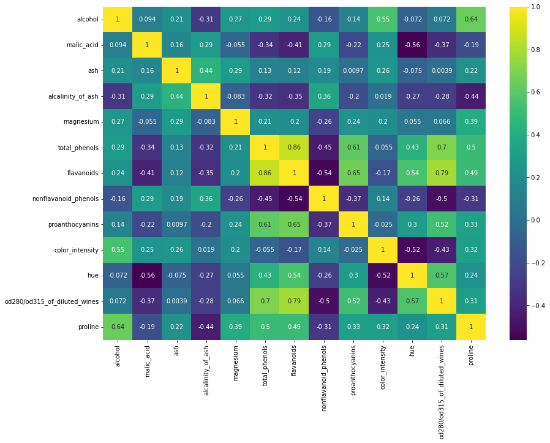

```python
## EJECUTAR ESTE BLOQUE

from sklearn.datasets import load_wine
import matplotlib.pyplot as plt
import seaborn as sns
import pandas as pd

wine = load_wine()
data = pd.DataFrame(data=wine['data'], columns=wine['feature_names'])

plt.figure(figsize=(14, 10))
sns.heatmap(data.corr(), cmap='viridis', annot=True);
```

### Respuesta a pregunta 1.2

Estas lineas de código importan las librerias necesarias, cargan la base de datos, hace un DataFrame de Pandas con los atributos y plotea la matriz de correlación entre los atributos mostrando las correlaciones y un color del mapa de calor asociado.

Estre gráfico permite identificar facilmente las variables con mayor dependencia entre sí (valores cercanos a 1 o -1, por ejemplo flavanoids con total_phenols).

Justamente las principales observaciones que se pueden obtener son del tipo "x atributo depende mucho de otro atributo y", por ejemplo, flavanoids con total_phenols tienen una correlación de aproximadamente 0.86, lo que significa que en general una fila con flavanoids alto significa que total_phenols probablemente será alto también.

Más generalmente: si dos atributos (x e y) poseen una correlación cercana a 1, significa que cuando un atributo es alto, el otro tiende a ser alto también.

Si la corr. es cercana a -1, cuando x es elevado y tiende a ser más bajo (y viceversa).

Y si la corr. es cerca de 0, esto nos dice que no hay dependencia entre los atributos.